# Time Series Analysis of French Electricity Consumption: 2024-2025 Project

#### 4.1. Alternative SARIMA MODEL: SARIMA(1,1,1)(0,1,1)[12]

```r
manual_fit <- Arima(ts_train, order = c(1,1,1),
                    seasonal = list(order = c(0,1,1), period = 12),
                    include.drift = FALSE)  # usually better to exclude drift when d=1
summary(manual_fit)
```

```
## Series: ts_train
## ARIMA(1,1,1)(0,1,1)[12]
##
## Coefficients:
##          ar1      ma1     sma1
##       0.3651  -0.9689  -1.0000
## s.e.  0.0821   0.0404   0.1472
##
## sigma^2 = 3428576:  log likelihood = -1375.45
## AIC=2758.9   AICc=2759.17   BIC=2770.99
##
## Training set error measures:
##                     ME     RMSE      MAE        MPE     MAPE      MASE
## Training set -254.2903 1759.576 1236.777 -0.7515563 3.069451 0.5693571
##                     ACF1
## Training set -0.02769854
```

##### Model Parameters, Information Criteria and Training errors measures

- AR (ar1 = 0.3651): significant (standard error much smaller than the coefficient).
- MA (ma1 = -0.9689): practically -1, indicating a strong moving average component.
- Seasonal MA (sma1 = -1.0000): extreme value, suggesting strong seasonal dependence. The standard error is reasonable (0.1472), so it’s probably significant too.

The coefficientes make sense and seem well estimated.

To increase confidence in the model, we will check the residuals:

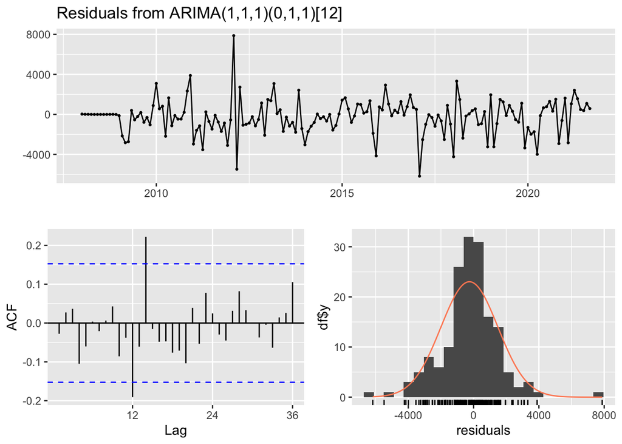

```
##
##  Ljung-Box test
##
## data:  Residuals from ARIMA(1,1,1)(0,1,1)[12]
## Q* = 28.317, df = 21, p-value = 0.1314
##
## Model df: 3.   Total lags used: 24
```

```r
checkresiduals(manual_fit)
```

The diagnostic plots show:

- The residuals plot shows no obvious patterns, appearing random around a mean of zero.
- The ACF plot of residuals have one or two significant spikes which means in general there is no correlation between the residuals.
- The Ljung-Box test has a large p-value (0.13), meaning we cannot reject the null hypothesis that the residuals are independently distributed. The model successfully passes the diagnostic checks, since the residuals behave like white noise, without patterns and non-autocorrelated, exactly like the other SARIMA model tested.

#### 4.2. Future Observations Forecast for SARIMA(1,1,1)(0,1,1)[12]

The forecast generated by the SARIMA(1,1,1)(0,1,1)[12] model for future data was evaluated against the actual values of the test set. The main results are presented below:

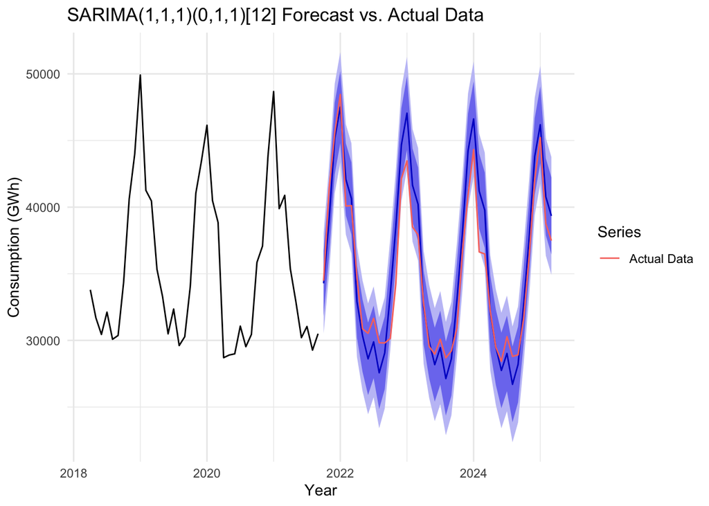

```r
# Forecast with manual SARIMA
sarima_manual_forecast <- forecast(manual_fit, h = length(ts_test))

# Plot forecasts
autoplot(sarima_manual_forecast, include = forecast_horizon) +
  autolayer(ts_test, series = "Actual Data") +
  labs(title = "SARIMA(1,1,1)(0,1,1)[12] Forecast vs. Actual Data",
       x = "Year", y = "Consumption (GWh)") +
  guides(colour = guide_legend(title = "Series")) +
  theme_minimal()
```

The actual values (red line) mostly remain within the 95% confidence intervals, suggesting that the model adequately captures the trend and variability of the series during the forecast period. Furthermore, the seasonal patterns observed in the actual data are well reproduced by the model, indicating a good fit to the seasonality present in the series.

The widening of the bands over time highlights the increasing uncertainty as the forecast extends further into the future, which is expected and characteristic of time series models.

```r
# Forecast accuracy
accuracy(sarima_manual_forecast, ts_test)
```

```
##                     ME     RMSE      MAE        MPE     MAPE      MASE
## Training set -254.2903 1759.576 1236.777 -0.7515563 3.069451 0.5693571
## Test set     -631.7464 2016.456 1659.371 -1.4554391 4.673250 0.7639005
##                     ACF1 Theil's U
## Training set -0.02769854        NA
## Test set      0.65713280 0.5581256
```

The accuracy metrics, particularly the Mean Absolute Percentage Error (MAPE) on the test set (4.67%), is still a very good value. This demonstrates a high level of accuracy. Theil’s U = 0.558: a value below 1 indicates that the model outperforms a naive prediction, validating its predictive utility.

When we evaluated the test set, we observed a natural increase in absolute and percentage errors, although these remained at acceptable levels (MAPE of 4.67%). However, there was also a significant increase in the autocorrelation of the residuals (ACF1 = 0.657), which suggests that the model could be improved by testing other SARIMA orders, for example, as part of the structure of the future data has not been captured. In terms of possible overfitting, it’s not a severe overfitting, but there are signs of underfitting to the new behaviour of the series, possible limitation in the ability to generalise.

#### 5.1 Alternative Model: STL

We will now model with STL (Seasonal-Trend Decomposition using Loess) that is a method of decomposing time series that divides them into three main components: trend, seasonality, and residuals. It helps prepare for modelling the residuals. Once trend and seasonality have been removed (already done - ts_stationary), the residuals can be modelled more accurately using models such as ETS. STL can be adjusted to be less sensitive to extreme values and more robust to outliers. This model allows unstructured fluctuations to be modelled separately with an ARIMA model. This strategy becomes useful when there is complexity or non-linear variation in the seasonal components.

```r
stlm_fit <- stlm(ts_train, s.window = "periodic", method = "arima")
stlm_fit$model
```

```
## Series: x
## ARIMA(2,1,1)
##
## Coefficients:
##          ar1     ar2      ma1
##       0.3385  0.0386  -0.9154
## s.e.  0.0854  0.0836   0.0341
##
## sigma^2 = 3291384:  log likelihood = -1462.31
## AIC=2932.62   AICc=2932.87   BIC=2945.02
```

```r
summary(stlm_fit)
```

```
##               Length Class          Mode
## stl           660    mstl           numeric
## model          18    forecast_ARIMA list
## modelfunction   1    -none-         function
## lambda          0    -none-         NULL
## x             165    ts             numeric
## series          1    -none-         character
## m               1    -none-         numeric
## fitted        165    ts             numeric
## residuals     165    ts             numeric
```

The ARIMA model adjusted after the STL decomposition was ARIMA(2,1,1).

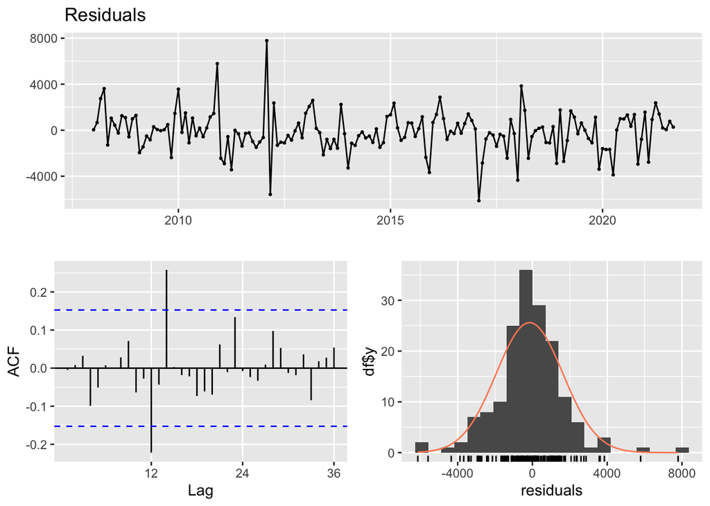

```
##
##  Ljung-Box test
##
## data:  Residuals
## Q* = 32.585, df = 24, p-value = 0.1131
##
## Model df: 0.   Total lags used: 24
```

```r
checkresiduals(stlm_fit)
```

The diagnostic plots show:

- The residuals plot shows no obvious patterns, appearing random around a mean of zero.
- The ACF plot of residuals have one or two significant spikes which means in general there is no correlation between the residuals.
- The Ljung-Box test has a large p-value (0.11), meaning we cannot reject the null hypothesis that the residuals are independently distributed. The model successfully passes the diagnostic checks, since the residuals behave like white noise, without patterns and non-autocorrelated.

The STL + ARIMA model was effective in capturing the seasonal and trend patterns of the series. Analysis of the residuals shows no significant autocorrelation, suggesting that the model is adequate and has left no unmodelled systematic patterns.

#### 5.2. Future Observations Forecast for STL model

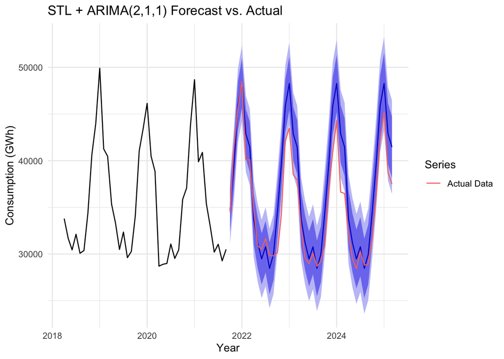

```r
# Forecast with STL + ARIMA
stlm_forecast <- forecast(stlm_fit, h = length(ts_test))

# Plot forecasts
autoplot(stlm_forecast, include = forecast_horizon) +
  autolayer(ts_test, series = "Actual Data") +
  labs(title = "STL + ARIMA(2,1,1) Forecast vs. Actual",
       x = "Year", y = "Consumption (GWh)") +
  guides(colour = guide_legend(title = "Series")) +
  theme_minimal()
```

The actual values (red line), for the most part, remain within the 95% confidence intervals, but unlike previous models, at times they fall only within the 80% range or even outside the intervals. Still, the model manages to capture the trend and variability of the time series well for most of the forecast horizon. The seasonal patterns present in the data are adequately represented, reflecting good performance of the seasonal decomposition performed by STL.

The widening of the bands over time highlights the natural increase in uncertainty for more distant periods, an expected behavior in time series forecasts.

```r
# Forcast accuracy
accuracy(stlm_forecast, ts_test)
```

```
##                      ME     RMSE      MAE        MPE     MAPE      MASE
## Training set  -154.9727 1792.092 1284.789 -0.5790029 3.174841 0.5914597
## Test set     -1975.0121 2879.010 2292.354 -5.3710130 6.317898 1.0552978
##                      ACF1 Theil's U
## Training set -0.004816872        NA
## Test set      0.696125655 0.7794289
```

Observing the forecasts plot we can observe that the forecasts capture the essence. This model has good training performance where the training residuals are practically white noise (ACF1 ≈ 0) and MASE < 1 and MAPE ≈ 3% indicate good in-sample performance. However, we verify a worse performance in the testwhere all errors increased significantly in the test and MASE > 1. ACF1 = 0.69 in the test suggests strong autocorrelation in the errors, which indicates underfitting to the most recent data - perhaps new patterns were not captured by the model which indicates of out-of-sample underfitting. The model seems not to have been able to capture recent changes or patterns specific to the test period that can be caused by recent structural changes or ARIMA model in the residuals with inappropriate order.

#### 6.1. Alternative Model: Exponential Smoothing (ETS)

We will now fit an ETS model to the training data. The ets() function in the forecast package automatically selects the best model by testing different combinations of error, trend, and seasonality components (additive, multiplicative, damped, etc.) and choosing the one with the lowest AICc. This model is useful for time series with systematic components, such as trends and/or seasonality, but with low noise. However, this model does not focus on stationarity, where differentiations are undesirable.

```r
# Fit an ETS model to the training data
ets_fit <- ets(ts_train)
summary(ets_fit)
```

```
## ETS(M,N,M)
##
## Call:
## ets(y = ts_train)
##
##   Smoothing parameters:
##     alpha = 0.2592
##     gamma = 1e-04
##
##   Initial states:
##     l = 40906.018
##     s = 1.243 1.0857 0.9475 0.8328 0.7968 0.8592
##            0.8235 0.8708 0.9344 1.1363 1.1667 1.3032
##
##   sigma:  0.0445
##
##      AIC     AICc      BIC
## 3314.285 3317.507 3360.874
##
## Training set error measures:
##                     ME    RMSE      MAE        MPE    MAPE      MASE     ACF1
## Training set -111.0541 1824.54 1313.975 -0.4202313 3.22943 0.6048954 0.157429
```

##### Smoothing parameters

Parameter Value Interpretation alpha: 0.2592 - moderate value, indicates that the model gives weight to both recent and past observations for the level. gamma: 1e-04 - practically zero, seasonality practically fixed over the period, not very adaptive.

The vector s represents the seasonal components for the 12 periods of the seasonal cycle (months). The seasonality values show variations over the months, with some months showing higher values (winter months).

The sigma value is 0.0445, indicates the residual variability of the model and a relatively low value suggests controlled residuals. The criteria information values are much larger than the previous ones, indicating that this is not the best adjusted model for this time series.

Next, we perform diagnostic checks on the ETS model’s residuals.

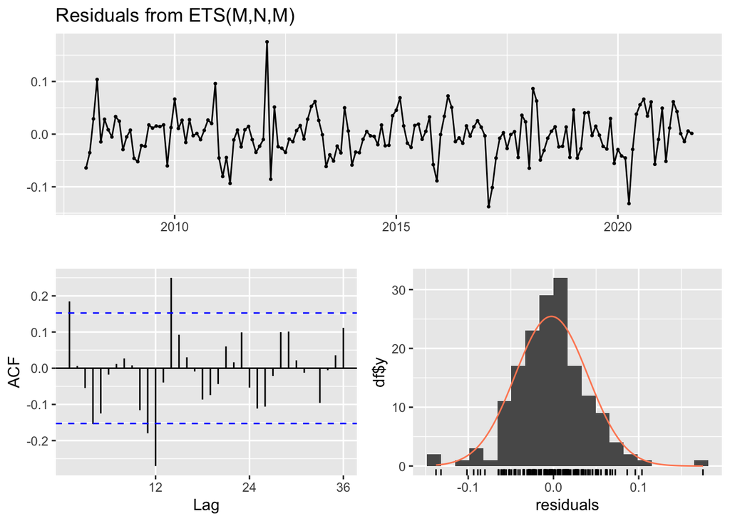

```
##
##  Ljung-Box test
##
## data:  Residuals from ETS(M,N,M)
## Q* = 53.978, df = 24, p-value = 0.0004292
##
## Model df: 0.   Total lags used: 24
```

```r
# Perform residual diagnostics for the ETS model
checkresiduals(ets_fit)
```

The diagnostic plots show:

The model does not passes successfully the diagnostic checks since the residuals do not behave like white noise.

#### 6.2. Future Observations Forecast for ETS model

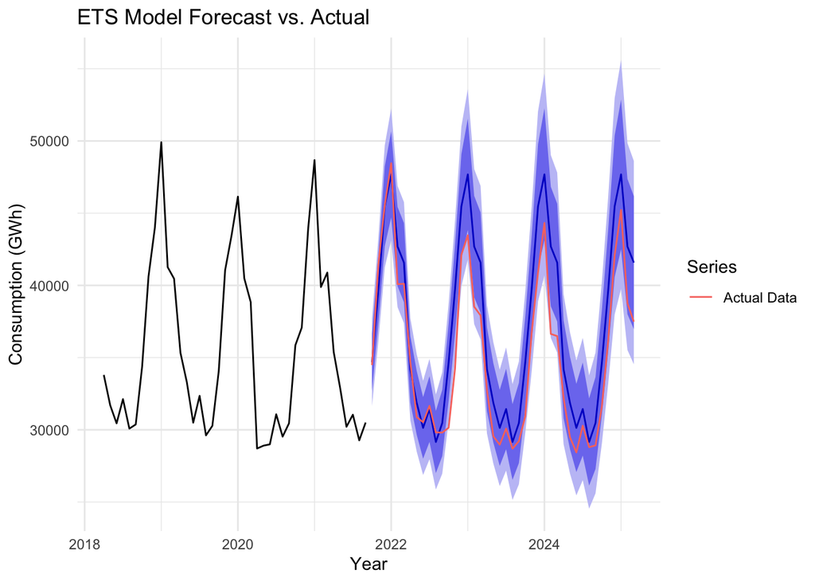

```r
# Generate forecasts using the fitted ETS model
ets_forecast <- forecast(ets_fit, h = length(ts_test))

autoplot(ets_forecast, include = forecast_horizon) +
  autolayer(ts_test, series = "Actual Data") +
  labs(title = "ETS Model Forecast vs. Actual",
       x = "Year", y = "Consumption (GWh)") +
  guides(colour = guide_legend(title = "Series")) +
  theme_minimal()
```

The observed values (Red line), for the most part, remain within the 95% confidence intervals, suggesting that the model effectively captures both the trend and the variability of the series. Moreover, the regular seasonal patterns are well represented, with the intervals successfully capturing the extremes of the historical series, indicating a good fit of the model to the seasonality.

The widening of the bands over time reveals the increasing uncertainty in longer-term forecasts, a typical and expected behavior in time series models.

```r
# Calculate accuracy metrics
accuracy(ets_forecast, ts_test)
```

```
##                      ME     RMSE      MAE        MPE     MAPE      MASE
## Training set  -111.0541 1824.540 1313.975 -0.4202313 3.229430 0.6048954
## Test set     -2149.3766 2856.831 2356.847 -6.0522804 6.604214 1.0849874
##                   ACF1 Theil's U
## Training set 0.1574290        NA
## Test set     0.6504006 0.7871231
```

In the training set, the model fits well, with relatively low error rates (MAPE ≈ 3.2%) and better performance than the naive model (MASE < 1). However, in the test set, errors increase significantly (MAPE >6%, MASE >1), indicating poorer out-of-sample performance. Additionally, the high residual autocorrelation in the test set (ACF1 ≈ 0.65) suggests that the model did not fully capture the series’ patterns, possibly due to underfitting or changes in the data’s dynamics.

### 7. Compare Models Results

#### Model Information Criteria Comparison

In addition to error metrics, information criteria such as AIC (Akaike Information Criterion), AICc (corrected AIC) and BIC (Bayesian Information Criterion) are fundamental to assessing model fit, considering adherence to the data and model complexity.

These criteria penalise overly complex models and help avoid overfitting. They are particularly useful for comparing models fitted to the same set of data.

```r
criteria <- data.frame(
  Model = c("SARIMA_auto", "SARIMA_manual", "ETS", "STLM_ARIMA"),
  AIC = c(AIC(auto_fit), AIC(manual_fit), ets_fit$aic, AIC(stlm_fit$model)),
  AICc = c(AICc(auto_fit), AICc(manual_fit), ets_fit$aicc, AICc(stlm_fit$model)),
  BIC = c(BIC(auto_fit), BIC(manual_fit), ets_fit$bic, BIC(stlm_fit$model))
)

criteria_num <- criteria
criteria_num[, -1] <- round(criteria[, -1], 2)
kable(criteria_num, caption = "Comparison of Information Criteria across Models") %>%
  kable_styling(bootstrap_options = c("striped"), full_width = FALSE)
```

Comparison of Information Criteria across Models

| Model | AIC | AICc | BIC |
| --- | --- | --- | --- |
| SARIMA_auto | 2767.64 | 2768.05 | 2782.80 |
| SARIMA_manual | 2758.90 | 2759.17 | 2770.99 |
| ETS | 3314.29 | 3317.51 | 3360.87 |
| STLM_ARIMA | 2932.62 | 2932.87 | 2945.02 |

When the AIC, AICc and BIC criteria are compared between the models, it can be seen that the SARIMA_manual model has the lowest values for all metrics, indicating a better balance between fit and model complexity. The SARIMA_auto model performed similarly, but slightly less well. In contrast, the STLM_ARIMA and ETS models had significantly higher values, suggesting that they fit the data less efficiently, possibly due to greater complexity or an inability to capture the patterns in the series. Therefore, based on the information criteria, the SARIMA_manual model is the most suitable for this time series.

#### Comparison of Model Forecast Accuracy on Test Set

To evaluate the predictive ability of the various models, we examined the error metrics in the test set. The metrics considered were RMSE (root mean squared error), MAE (mean absolute error), MAPE (mean absolute percentage error) and Theil’s U. These metrics provide different perspectives on the quality of the forecasts.

The table below summarises these metrics for the four evaluated models: SARIMA with automatic parameter selection (SARIMA_auto); SARIMA with manual parameters (SARIMA_manual); the ETS model; and the hybrid STLM model with ARIMA in the residuals (STLM_ARIMA). The aim of this comparison is to identify the model with the best predictive performance and the lowest error in forecasting future values of the series.

```r
library(knitr)

results <- rbind(
  SARIMA_auto = accuracy(sarima_forecast, ts_test)[2, c("RMSE", "MAE", "MAPE", "Theil's U")],
  SARIMA_manual = accuracy(sarima_manual_forecast, ts_test)[2, c("RMSE", "MAE", "MAPE", "Theil's U")],
  ETS = accuracy(ets_forecast, ts_test)[2, c("RMSE", "MAE", "MAPE", "Theil's U")],
  STLM_ARIMA = accuracy(stlm_forecast, ts_test)[2, c("RMSE", "MAE", "MAPE", "Theil's U")]
)
kable(round(results, 2), caption = "Forecast Accuracy Comparison on Test Set") %>%
  kable_styling(bootstrap_options = c("striped", "hover", "condensed"), full_width = FALSE)
```

Forecast Accuracy Comparison on Test Set

|  | RMSE | MAE | MAPE | Theil’s U |
| --- | --- | --- | --- | --- |
| SARIMA_auto | 1860.80 | 1547.57 | 4.38 | 0.52 |
| SARIMA_manual | 2016.46 | 1659.37 | 4.67 | 0.56 |
| ETS | 2856.83 | 2356.85 | 6.60 | 0.79 |
| STLM_ARIMA | 2879.01 | 2292.35 | 6.32 | 0.78 |

When the models were compared based on the forecasting metrics in the test set, the SARIMA_auto model exhibited the best overall performance, showing the lowest RMSE, MAE, MAPE and Theil’s U values. This indicates greater accuracy and better predictive capacity. SARIMA_manual performed reasonably well, albeit slightly less well than the automatic model. The ETS and STLM_ARIMA models, on the other hand, produced significantly higher error values, suggesting that they are less effective for forecasting this series. Therefore, the automatic SARIMA model is the most suitable choice for future forecasting.

#### Visualising forecasts

In addition to quantitative metrics, visually comparing the predictions with the actual data is fundamental to understanding how each model behaves over time. The graph below shows the actual values of the test set alongside the forecasts generated by each model.

This visualisation enables us to identify any systematic deviations, as well as the models’ ability to capture seasonality and trends, and any delays or one-off errors in the forecasts.

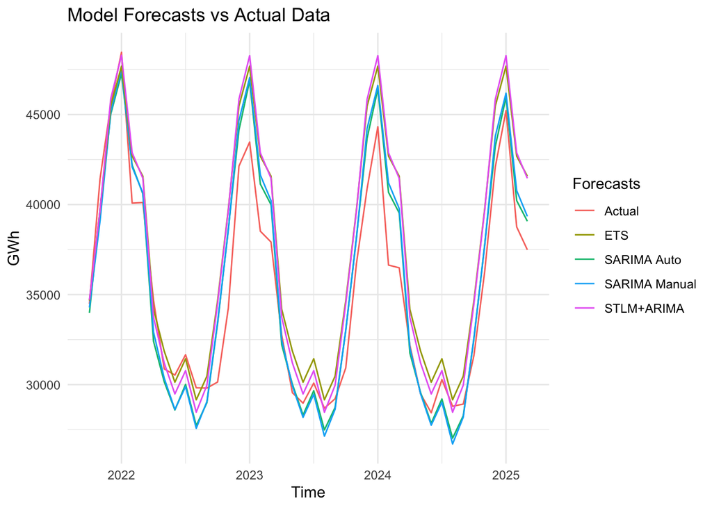

```r
autoplot(ts_test, series = "Actual") +
  autolayer(sarima_forecast$mean, series = "SARIMA Auto", PI = FALSE) +
  autolayer(sarima_manual_forecast$mean, series = "SARIMA Manual", PI = FALSE) +
  autolayer(ets_forecast$mean, series = "ETS", PI = FALSE) +
  autolayer(stlm_forecast$mean, series = "STLM+ARIMA", PI = FALSE) +
  labs(title = "Model Forecasts vs Actual Data", y = "GWh", x = "Time") +
  guides(colour = guide_legend(title = "Forecasts")) +
  theme_minimal()
```

By comparing the model forecasts with the actual data, we conclude that SARIMA_auto and SARIMA_manual produced the most accurate predictions.

#### Final conclusions and Discussion

When analysing the information criteria (AIC, AICc and BIC) and forecast accuracy metrics (RMSE, MAE, MAPE and Theil’s U) in the test set, the SARIMA_auto and SARIMA_manual models emerged as the most suitable for modelling the time series.

SARIMA_manual produced the lowest information criterion values, indicating the best balance between model fit and complexity. However, SARIMA_auto obtained the lowest forecast errors in terms of predictive performance, suggesting greater capacity for generalisation and accuracy in future data.

Conversely, the ETS and STLM_ARIMA models exhibited significantly higher values in both the information criteria and the error metrics, suggesting poorer model fit and forecasting performance.

Therefore, the ideal choice depends on the objective: SARIMA_manual is more suitable for better historical adjustment, while SARIMA_auto is superior for future forecasting with lower error. Overall, SARIMA models are more appropriate for this data than ETS and STLM_ARIMA models. By comparing the models’ forecasts with the actual data, we can conclude that SARIMA_auto and SARIMA_manual produced the most accurate predictions.